# Equipo 1

## Contexto

Un equipo de investigadores del área de interacción humano-información está estudiando si el área temática y el nivel de dificultad del problema de información influyen en el tiempo (en segundos) que toma un usuario en formular una consulta de búsqueda para resolver dicho problema. Para ello, han reclutado a un grupo de participantes voluntarios, asignados aleatoriamente a distintos grupos. Cada participante debe resolver tres problemas de información con diferentes niveles de dificultad: baja, media y alta.

En este momento, los investigadores buscan determinar si existen diferencias en el tiempo que tardan los usuarios en formular consultas para problemas con diferente nivel de dificultad en el área de física.

### Solucion

Para empezar, es necesario extraer los datos para el analisís, en este caso se nos pregunta si es que existe diferencias en el tiempo de consultas en relación a la dificultad de la pregunta en al área de física.

```r
datos <- read.csv("EP06 Datos.csv",stringsAsFactors = TRUE)
datos_fisica <- datos[datos$area == "Física",]
fisica_bajo <- datos_fisica[datos_fisica$dificultad == "Baja",]
fisica_medio <- datos_fisica[datos_fisica$dificultad == "Media",]
fisica_alto <- datos_fisica[datos_fisica$dificultad == "Alta",]
```

Con los datos necesarios ya extraidos, ahora es necesario establecer que tipo de test se llevará a cabo y posteriormente revisar que las condiciones previas se cumplan para utilizar la prueba.

En el contexto del ejercicio, se quiere averiguar si existen diferencias de tiempo considerando la dificultad ejercicio, es decir, determinar si la dificultad es un factor que genera diferencias en los tiempos de consulta. Por lo tanto, buscar una diferencia de proporciones en las muestras, caso donde el test ANOVA es perfecto.

Para llevar a cabo ANOVA pareado, es necesario que los datos cumplan las condiciones asociadas al test, las cuales son:

- La variable dependiente es medida con una escala de intervalos iguales

  En este caso, la escala es a través de segundos, donde la diferencia entre un valor de 94 y 95, es la misma distancia entre 93 y 94, es decir, la diferencia de 1 segundo es constante entre todos los valores.
- La población sigue una distribución normal

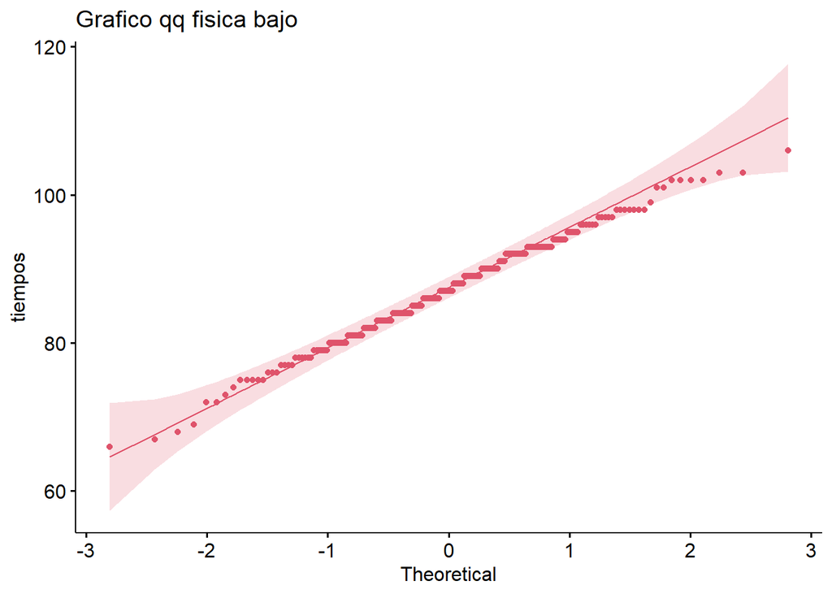

```r
gg_fisica = ggqqplot(data = data.frame(fisica_bajo$tiempo),x = "fisica_bajo$tiempo",main="Grafico qq fisica bajo",ylab="tiempos", color = 0x0912)

gg_fisica_media = ggqqplot(data = data.frame(fisica_medio$tiempo),x = "fisica_medio$tiempo",main="Grafico qq fisica medios",ylab="tiempos", color = 0x210F)

gg_fisica_alta = ggqqplot(data = data.frame(fisica_alto$tiempo),x = "fisica_alto$tiempo",main="Grafico qq fisica alta",ylab="tiempos", color = 0x18794)

print(gg_fisica)
```

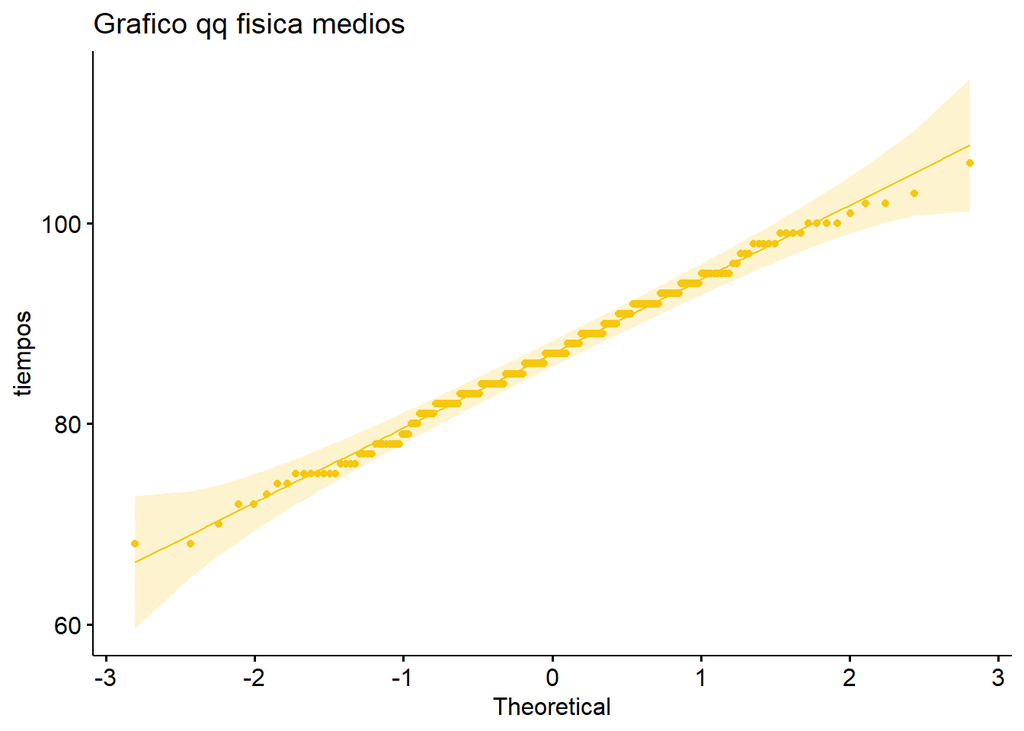

```r
print(gg_fisica_media)
```

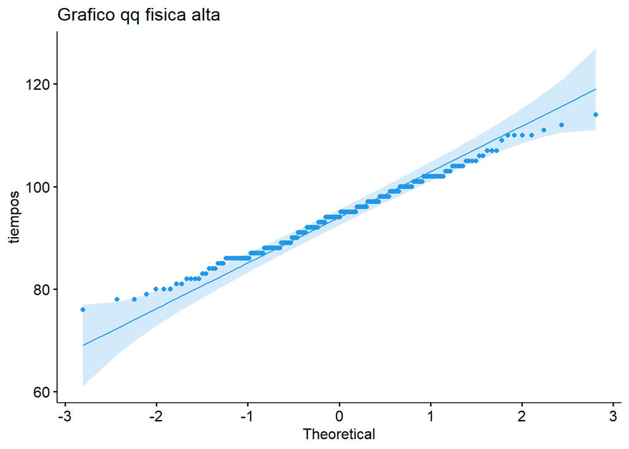

```r
print(gg_fisica_alta)
```

Analizando los graficos es facil observar el hecho de que todos siguen una distribución normal. Por lo que la ultima condición que queda por revisar, es la esferidicidad de las muestras. Esta prueba, existe dentro del mismo test ezANOVA que utilizaremos para comprobar los datos, por lo que dejaremos la aprobación de esta condición para después de recibir los resultados de la prueba.

Y las hipótesis son las siguientes:

$H_o :$ No existe una diferencia entre las proporciones de tiempo de consultas en las dificultades en el area de física.

$H_a :$ Existe una diferencia entre las proporciones de tiempo de consultas en las dificultades en el area de física.

```r
largo = factor(1:200)
dataframe = data.frame(largo, fisica_bajo,fisica_medio,fisica_alto)

datos_largos <- datos |> filter(area == "Física") |> select(id,dificultad,tiempo) |> droplevels()

prueba <- ezANOVA(data = datos_largos, dv = tiempo, within = dificultad, wid = id, return_aov = TRUE)
print(prueba)
```

```
## $ANOVA
##       Effect DFn DFd        F            p p<.05       ges
## 2 dificultad   2 398 70.71079 5.284426e-27     * 0.1694951
##
## $`Mauchly's Test for Sphericity`
##       Effect         W        p p<.05
## 2 dificultad 0.9990732 0.912293
##
## $`Sphericity Corrections`
##       Effect       GGe       p[GG] p[GG]<.05      HFe        p[HF] p[HF]<.05
## 2 dificultad 0.9990741 5.56544e-27         * 1.009203 5.284426e-27         *
##
## $aov
##
## Call:
## aov(formula = formula(aov_formula), data = data)
##
## Grand Mean: 89.43
##
## Stratum 1: id
##
## Terms:
##                 Residuals
## Sum of Squares   14422.39
## Deg. of Freedom       199
##
## Residual standard error: 8.513186
##
## Stratum 2: id:dificultad
##
## Terms:
##                 dificultad Residuals
## Sum of Squares     6915.24  19461.43
## Deg. of Freedom          2       398
##
## Residual standard error: 6.992715
## Estimated effects may be unbalanced
```

Con esta prueba se pueden extraer dos conclusiones importantes. En primer lugar, el valor p de la prueba de esfericidad de Mauchly es 0.912, lo cual es mayor a 0.05. Esto indica que se cumple el supuesto de esfericidad, cumpliendo así la cuarta condición necesaria para aplicar un ANOVA de medidas repetidas.

En segundo lugar, el ANOVA muestra un valor p extremadamente bajo (< 0.05), lo que nos permite rechazar la hipótesis nula. Esto significa que sí existen diferencias significativas en el tiempo de respuesta según la dificultad de las preguntas. Además, dado que el valor p es considerablemente menor al umbral convencional, podemos afirmar esta conclusión con un nivel de confianza superior al 99%.

Dado que se rechazó la hipótesis nula en el ANOVA, se procedió a realizar un análisis post hoc con el fin de obtener información más detallada sobre las diferencias entre los niveles del factor dificultad.

```r
alfa = 0.05
mixto <- lme(tiempo~dificultad , data = datos_largos, random = ~1|id)
medias <- emmeans(mixto,"dificultad")

hsd <- contrast(medias , method = "pairwise", adjust = "tukey")

scheffe <- contrast(medias, method = "pairwise",adjust = "scheffe")

print(hsd, infer = TRUE, level = 1 - alfa)
```

```
##  contrast     estimate    SE  df lower.CL upper.CL t.ratio p.value
##  Alta - Baja      7.11 0.699 398     5.46     8.76  10.168  <.0001
##  Alta - Media     7.29 0.699 398     5.64     8.94  10.425  <.0001
##  Baja - Media     0.18 0.699 398    -1.47     1.83   0.257  0.9641
##
## Degrees-of-freedom method: containment
## Confidence level used: 0.95
## Conf-level adjustment: tukey method for comparing a family of 3 estimates
## P value adjustment: tukey method for comparing a family of 3 estimates
```

```r
print(scheffe, infer = TRUE, level = 1 - alfa)
```

```
##  contrast     estimate    SE  df lower.CL upper.CL t.ratio p.value
##  Alta - Baja      7.11 0.699 398     5.39     8.83  10.168  <.0001
##  Alta - Media     7.29 0.699 398     5.57     9.01  10.425  <.0001
##  Baja - Media     0.18 0.699 398    -1.54     1.90   0.257  0.9674
##
## Degrees-of-freedom method: containment
## Confidence level used: 0.95
## Conf-level adjustment: scheffe method with rank 2
## P value adjustment: scheffe method with rank 2
```

Con el analisis de resultados, podemos ver que existe una diferencia significativa entre la dificultad alta en comparación a las dificultades media y baja, además que entre las mismas, no existe una diferencia significativa, lo que se ve con su p-value de 0,9674.

Con base en todos los análisis realizados, se puede responder a la pregunta original: sí existe una diferencia significativa en el tiempo que tardan los usuarios en realizar una consulta según la dificultad de la pregunta. Esta diferencia se manifiesta principalmente en la condición de dificultad alta, la cual se distingue significativamente de las condiciones media y baja. En contraste, no se encontraron diferencias significativas en los tiempos de respuesta entre las dificultades media y baja.